# Arianna Final

It is important to consider environemental facotors when it comes to certain segments. For example, the paddle can be influenced by currents, waves, and other factors that are not presented as heavily cdin the other segments. This can lead to a higher variance in paddle times compared to other segments, making it a more important factor in determining what has the greatest impact. It can really be out of your control when a set is coming. For example, you might be in the very back of the race, but with the right time and right wave, you can catch up to the front of the pack and even surpace them.

```
Average Segment Times by Performance Group:
                           Ski       Run 1         Swim        Board  \
Performance_Group
Top                6988.368421  250.684211  3111.052632  2865.736842
Upper-Middle       7769.473684  282.842105  3445.894737  3267.789474
Lower-Middle       8399.611111  308.666667  3853.500000  3644.555556
Bottom             8838.263158  359.578947  4451.947368  4260.894737

                         Run 2
Performance_Group
Top                2223.789474
Upper-Middle       2504.421053
Lower-Middle       2759.333333
Bottom             2909.052632

Differences (Bottom - Top) in Segment Times (in seconds):
Ski      1849.894737
Run 1     108.894737
Swim     1340.894737
Board    1395.157895
Run 2     685.263158
dtype: float64
```

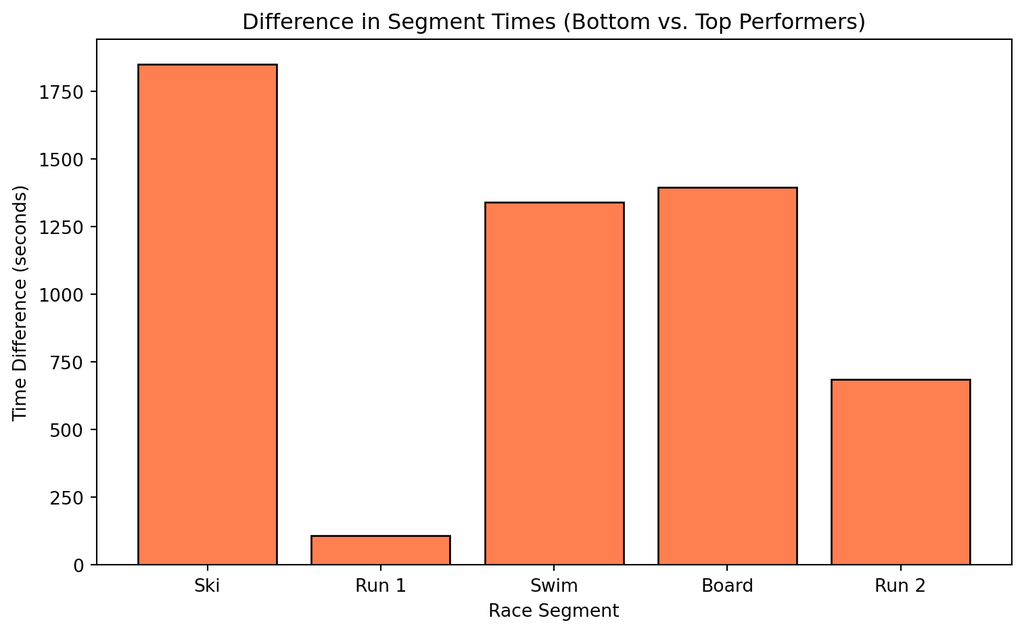

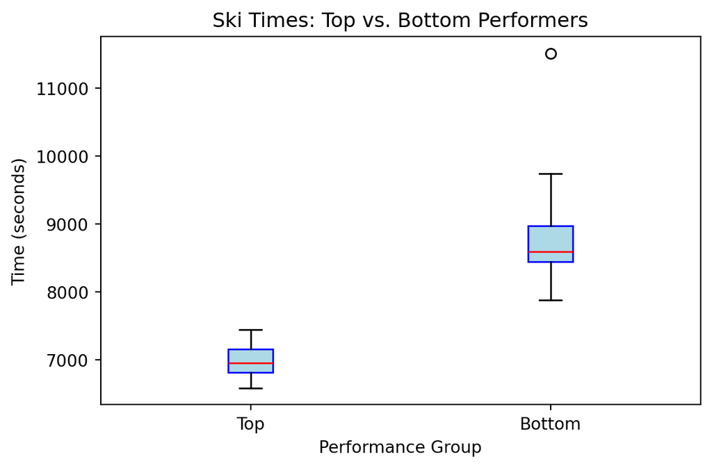

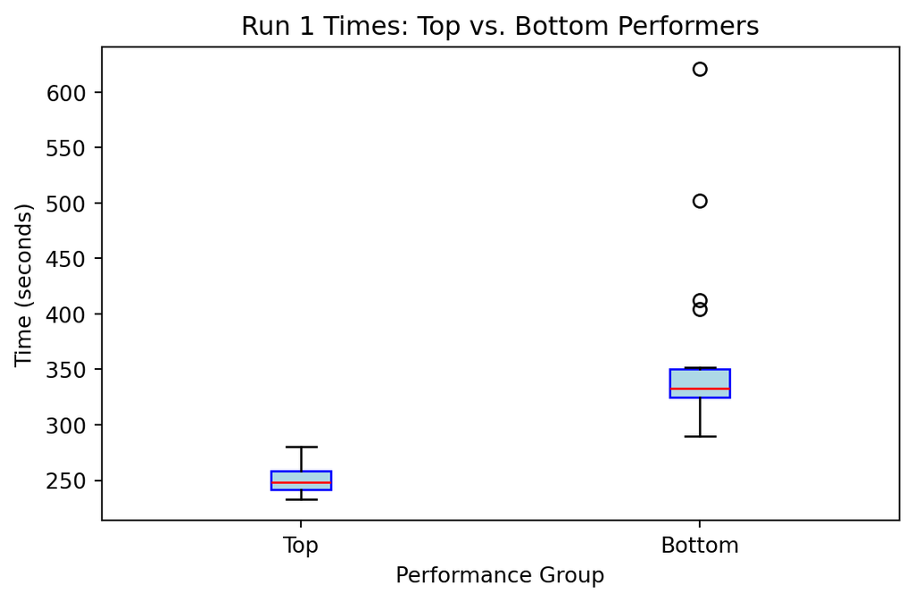

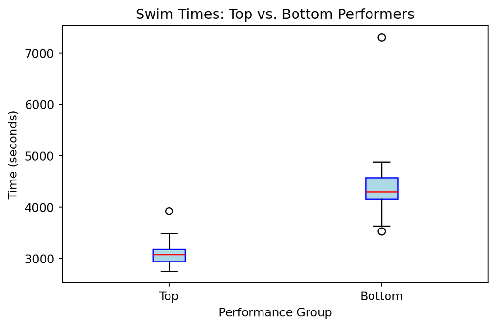

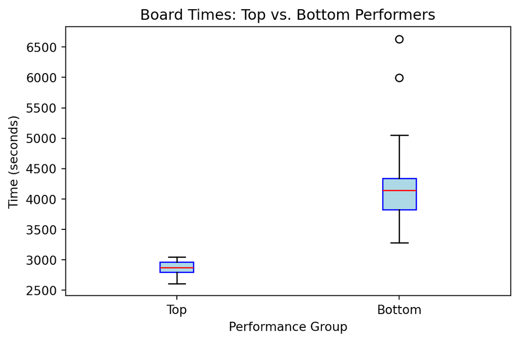

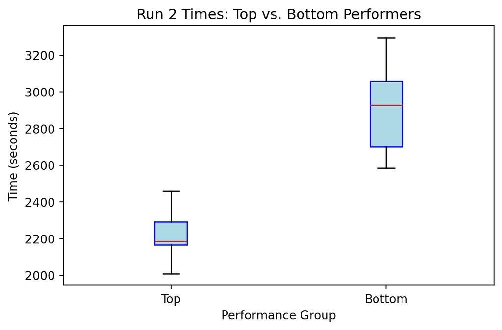

```python
df_sorted = df_athletes.sort_values(by='Gun Time')


df_sorted['Performance_Group'] = pd.qcut(df_sorted['Gun Time'], q=4, labels=['Top', 'Upper-Middle', 'Lower-Middle', 'Bottom'])


segment_columns = ['Ski', 'Run 1', 'Swim', 'Board', 'Run 2']


group_means = df_sorted.groupby('Performance_Group')[segment_columns].mean()
print("Average Segment Times by Performance Group:")
print(group_means)

diffs = group_means.loc['Bottom'] - group_means.loc['Top']
print("\nDifferences (Bottom - Top) in Segment Times (in seconds):")
print(diffs)


plt.figure(figsize=(8, 5))
plt.bar(diffs.index, diffs.values, color='coral', edgecolor='black')
plt.title("Difference in Segment Times (Bottom vs. Top Performers)")
plt.xlabel("Race Segment")
plt.ylabel("Time Difference (seconds)")
plt.tight_layout()
plt.show()


top_group = df_sorted[df_sorted['Performance_Group'] == 'Top']
bottom_group = df_sorted[df_sorted['Performance_Group'] == 'Bottom']

for seg in segment_columns:
    data_to_plot = [top_group[seg].values, bottom_group[seg].values]
    plt.figure(figsize=(6, 4))
    plt.boxplot(data_to_plot, labels=['Top', 'Bottom'], patch_artist=True,
                boxprops=dict(facecolor='lightblue', color='blue'),
                medianprops=dict(color='red'))
    plt.title(f"{seg} Times: Top vs. Bottom Performers")
    plt.xlabel("Performance Group")
    plt.ylabel("Time (seconds)")
    plt.tight_layout()
    plt.show()
```